# ISLR_Ch4_LogisticRegression

## 4.6.3 Linear Discriminant Analysis

Now we will perform **LDA** on `Smarket` using `lda()` from `MASS` (identical to `lm()` + `glm()`except for absence of `family` arg)

```r
library(MASS)
lda_fit <- lda(Direction ~ Lag1 + Lag2, train)
lda_fit
```

```
## Call:
## lda(Direction ~ Lag1 + Lag2, data = train)
##
## Prior probabilities of groups:
##     Down       Up
## 0.491984 0.508016
##
## Group means:
##             Lag1        Lag2
## Down  0.04279022  0.03389409
## Up   -0.03954635 -0.03132544
##
## Coefficients of linear discriminants:
##             LD1
## Lag1 -0.6420190
## Lag2 -0.5135293
```

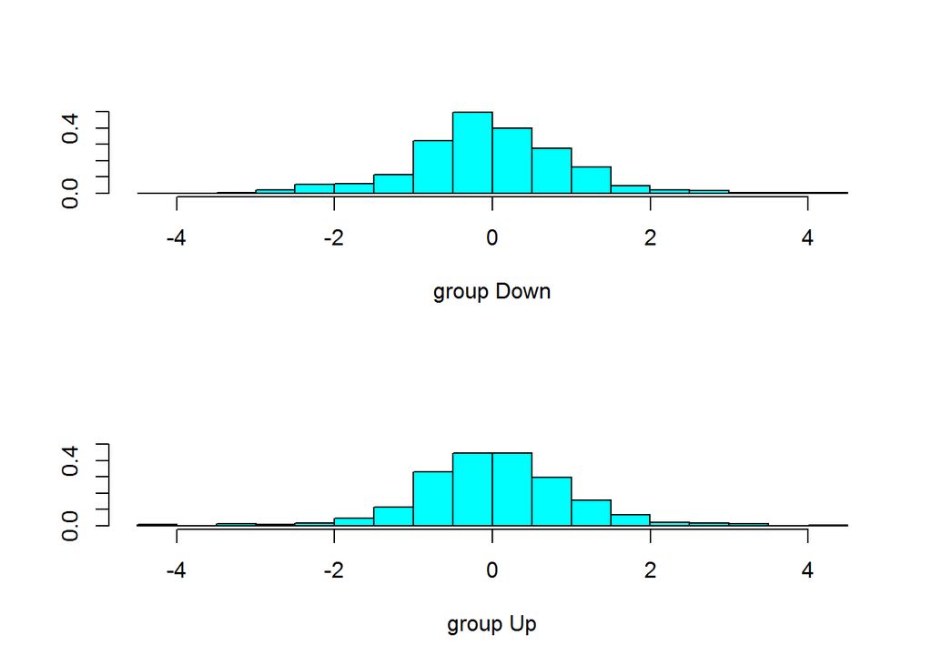

```r
plot(lda_fit)
```

```r
summary(lda_fit)
```

```
##         Length Class  Mode
## prior   2      -none- numeric
## counts  2      -none- numeric
## means   4      -none- numeric
## scaling 2      -none- numeric
## lev     2      -none- character
## svd     1      -none- numeric
## N       1      -none- numeric
## call    3      -none- call
## terms   3      terms  call
## xlevels 0      -none- list
```

LDA result indicates that $\hat{\pi}_{1}$ = 0.492 + $\hat{\pi}_{2}$ = 0.508; in other words, 49.2% of training observations correspond to days during which the market went down and 50.8% to days when it went up. It also provides **group means** = the average of *each predictor within each class (up/down in `lag1` and `lag2` respectively*, + are used by LDA as estimates of $\mu_k$.

These suggest there’s a tendency for the previous 2 days’ returns to be negative on days when the market increases, + a tendency for the previous days’ returns to be positive on days when the market declines. The **coefficients of linear discriminants** provides the *linear combination* of `Lag1` + `Lag2` that’re used to form the **LDA decision rule**. In other words, these $\beta$ = the **multipliers of the elements of $(X = x)$ w/in $\sigma_k(x) = x^{T}\sum^{-1}\mu_k - \frac {1} {2} \mu_k^{T}\sum^{-1}\mu_k + log(\pi_k)$**.

- vector/matrix version of $\sigma_k(x) = x\frac {\mu_k} {\sigma^2} - \frac {\mu_k^2} {2\sigma^2} + log(\pi_k)$

`predict()` will return a list w/ 3 elements = **`class`** = LDA’s predictions about the movement of the market, **`posterior`** = a matrix whose $k$th column contains the posterior probability that the corresponding observation belongs to the $k$th class, computed from (4.10) and **`x`** = contains the linear discriminants, described earlier.

```r
lda_preds <- predict(lda_fit,test)
names(lda_preds)
```

```
## [1] "class"     "posterior" "x"
```

```r
lda_preds$class
```

```
##   [1] Up   Up   Up   Up   Up   Up   Up   Up   Up   Up   Up   Down Up   Up
##  [15] Up   Up   Up   Down Up   Up   Down Down Down Up   Down Down Up   Up
##  [29] Up   Down Down Up   Up   Up   Up   Up   Up   Down Down Up   Up   Up
##  [43] Up   Down Down Up   Up   Up   Up   Up   Up   Up   Up   Up   Up   Up
##  [57] Up   Up   Up   Up   Down Down Up   Up   Down Down Down Up   Up   Up
##  [71] Up   Up   Up   Up   Down Up   Down Down Up   Up   Up   Up   Up   Down
##  [85] Up   Down Down Up   Up   Up   Up   Up   Up   Down Down Down Down Up
##  [99] Up   Up   Up   Up   Down Up   Up   Down Up   Up   Up   Up   Up   Up
## [113] Up   Up   Up   Up   Down Up   Up   Up   Up   Up   Up   Down Down Up
## [127] Up   Down Up   Up   Down Down Down Up   Up   Up   Up   Up   Down Up
## [141] Up   Up   Up   Down Down Up   Up   Down Down Up   Up   Up   Up   Up
## [155] Up   Up   Up   Up   Up   Up   Up   Up   Up   Up   Up   Up   Up   Up
## [169] Down Down Up   Down Down Up   Up   Up   Up   Up   Up   Down Up   Up
## [183] Up   Up   Up   Up   Up   Up   Down Down Up   Up   Up   Up   Up   Up
## [197] Up   Up   Up   Down Down Up   Down Up   Up   Down Down Up   Up   Down
## [211] Down Up   Down Down Up   Up   Up   Up   Down Down Up   Up   Up   Down
## [225] Down Down Down Down Up   Up   Up   Up   Down Down Up   Up   Up   Up
## [239] Up   Up   Down Down Up   Up   Up   Up   Up   Down Up   Up   Up   Up
## Levels: Down Up
```

```r
head(lda_preds$posterior)
```

```
##           Down        Up
## 999  0.4901792 0.5098208
## 1000 0.4792185 0.5207815
## 1001 0.4668185 0.5331815
## 1002 0.4740011 0.5259989
## 1003 0.4927877 0.5072123
## 1004 0.4938562 0.5061438
```

```r
head(lda_preds$x)
```

```
##              LD1
## 999   0.08293096
## 1000  0.59114102
## 1001  1.16723063
## 1002  0.83335022
## 1003 -0.03792892
## 1004 -0.08743142
```

```r
(cm <- table(lda_preds$class,test$Direction)) # confusion matrix
```

```
##
##        Down  Up
##   Down   35  35
##   Up     76 106
```

```r
accuracy <- (cm[4]+cm[1]) / sum(cm) # TP + TN / n OR  mean(glm_preds==Direction)

confusionMatrix(as.factor(lda_preds$class), test$Direction)
```

```
## Confusion Matrix and Statistics
##
##           Reference
## Prediction Down  Up
##       Down   35  35
##       Up     76 106
##
##                Accuracy : 0.5595
##                  95% CI : (0.4959, 0.6218)
##     No Information Rate : 0.5595
##     P-Value [Acc > NIR] : 0.5262856
##
##                   Kappa : 0.0698
##  Mcnemar's Test P-Value : 0.0001467
##
##             Sensitivity : 0.3153
##             Specificity : 0.7518
##          Pos Pred Value : 0.5000
##          Neg Pred Value : 0.5824
##              Prevalence : 0.4405
##          Detection Rate : 0.1389
##    Detection Prevalence : 0.2778
##       Balanced Accuracy : 0.5335
##
##        'Positive' Class : Down
##
```

```r
cat("\nTest Error Rate: ", 1 - accuracy)
```

```
##
## Test Error Rate:  0.4404762
```

Applying a 50% threshold to our posterior probabilities allows us to recreate the predictions contained in `lda.pred$class`.

```r
head(lda_preds$posterior)
```

```
##           Down        Up
## 999  0.4901792 0.5098208
## 1000 0.4792185 0.5207815
## 1001 0.4668185 0.5331815
## 1002 0.4740011 0.5259989
## 1003 0.4927877 0.5072123
## 1004 0.4938562 0.5061438
```

```r
sum(lda_preds$posterior[,1] >= .5) # check posterior probabilities of Down that are above or equal to threshold
```

```
## [1] 70
```

```r
sum(lda_preds$posterior[,1] < .5) # check posterior probabilities of Down that are below threshold
```

```
## [1] 182
```

Notice the **posterior probability output by the model = probability market will decrease**:

```r
data.frame("prob of down" = lda_preds$posterior[1:20,1],"classification"=lda_preds$class[1:20])
```

```
##      prob.of.down classification
## 999     0.4901792             Up
## 1000    0.4792185             Up
## 1001    0.4668185             Up
## 1002    0.4740011             Up
## 1003    0.4927877             Up
## 1004    0.4938562             Up
## 1005    0.4951016             Up
## 1006    0.4872861             Up
## 1007    0.4907013             Up
## 1008    0.4844026             Up
## 1009    0.4906963             Up
## 1010    0.5119988           Down
## 1011    0.4895152             Up
## 1012    0.4706761             Up
## 1013    0.4744593             Up
## 1014    0.4799583             Up
## 1015    0.4935775             Up
## 1016    0.5030894           Down
## 1017    0.4978806             Up
## 1018    0.4886331             Up
```

Suppose we wish to predict a market decrease *only if we’re very certain market will indeed decrease on that day* == i.e. if posterior probability is at least 90%.

```r
sum(lda_preds$posterior[,1] >= .9) # check posterior probabilities of Down that are above or equal to threshold
```

```
## [1] 0
```

```r
sum(lda_preds$posterior[,1] < .9) # check posterior probabilities of Down that are below threshold
```

```
## [1] 252
```

No days in 2005 meet that threshold! In fact, the greatest posterior probability of decrease in all of 2005 = 52.02%.

## 4.6.4 Quadratic Discriminant Analysis

Now fit a QDA model to Smarket via `qda()` from `MASS` w/ syntax identical to that of `lda()`.

```r
qda_fit <- qda(Direction ~ Lag1 + Lag2, train)
qda_fit
```

```
## Call:
## qda(Direction ~ Lag1 + Lag2, data = train)
##
## Prior probabilities of groups:
##     Down       Up
## 0.491984 0.508016
##
## Group means:
##             Lag1        Lag2
## Down  0.04279022  0.03389409
## Up   -0.03954635 -0.03132544
```

Output contains group means but does *not* contain the coefficients of the linear discriminants, b/c a QDA classifier involves a *quadratic* function, rather than a linear function, of the predictors. `predict()` works in exactly the same fashion as for LDA.

```r
qda_preds <- predict(qda_fit,test)
names(qda_preds)
```

```
## [1] "class"     "posterior"
```

```r
qda_preds$class
```

```
##   [1] Up   Up   Up   Up   Up   Up   Up   Up   Up   Up   Up   Down Up   Up
##  [15] Up   Up   Up   Down Up   Up   Up   Down Down Up   Down Down Up   Up
##  [29] Up   Down Up   Up   Up   Up   Up   Up   Up   Down Down Up   Up   Up
##  [43] Up   Down Down Up   Up   Up   Up   Up   Up   Up   Up   Up   Up   Up
##  [57] Up   Up   Up   Up   Down Down Up   Up   Up   Up   Up   Up   Up   Up
##  [71] Up   Up   Up   Up   Down Up   Down Down Up   Up   Up   Up   Up   Down
##  [85] Up   Down Down Up   Up   Up   Up   Up   Up   Up   Down Down Down Up
##  [99] Up   Up   Up   Up   Up   Up   Up   Down Up   Up   Up   Up   Up   Up
## [113] Up   Up   Up   Up   Up   Up   Up   Up   Up   Up   Up   Down Up   Up
## [127] Up   Down Up   Up   Down Down Up   Up   Up   Up   Up   Up   Down Up
## [141] Up   Up   Up   Up   Down Up   Up   Up   Up   Up   Up   Up   Up   Up
## [155] Up   Up   Up   Up   Up   Up   Up   Up   Up   Up   Up   Up   Up   Up
## [169] Up   Down Up   Down Down Up   Up   Up   Up   Up   Up   Down Up   Up
## [183] Up   Up   Up   Up   Up   Up   Down Down Up   Up   Up   Up   Up   Up
## [197] Up   Up   Up   Up   Down Up   Down Up   Up   Down Down Up   Up   Down
## [211] Down Up   Up   Down Up   Up   Up   Up   Down Down Up   Up   Up   Down
## [225] Down Down Down Up   Up   Up   Up   Up   Up   Down Up   Up   Up   Up
## [239] Up   Up   Up   Down Up   Up   Up   Up   Up   Up   Up   Up   Up   Up
## Levels: Down Up
```

```r
(cm <- table(qda_preds$class,test$Direction)) # confusion matrix
```

```
##
##        Down  Up
##   Down   30  20
##   Up     81 121
```

```r
accuracy <- (cm[4]+cm[1]) / sum(cm) # TP + TN / n OR  mean(glm_preds==Direction)

confusionMatrix(as.factor(qda_preds$class), test$Direction)
```

```
## Confusion Matrix and Statistics
##
##           Reference
## Prediction Down  Up
##       Down   30  20
##       Up     81 121
##
##                Accuracy : 0.5992
##                  95% CI : (0.5358, 0.6602)
##     No Information Rate : 0.5595
##     P-Value [Acc > NIR] : 0.1138
##
##                   Kappa : 0.1364
##  Mcnemar's Test P-Value : 2.369e-09
##
##             Sensitivity : 0.2703
##             Specificity : 0.8582
##          Pos Pred Value : 0.6000
##          Neg Pred Value : 0.5990
##              Prevalence : 0.4405
##          Detection Rate : 0.1190
##    Detection Prevalence : 0.1984
##       Balanced Accuracy : 0.5642
##
##        'Positive' Class : Down
##
```

```r
cat("\nTest Error Rate: ", 1 - accuracy)
```

```
##
## Test Error Rate:  0.4007937
```

Interestingly, QDA predictions = accurate ~60 % of the time, even though the 2005 (test) data was not used to fit the model. This level of accuracy is quite impressive for stock market data, which is known to be quite hard to model accurately.

*This suggests the quadratic form assumed by QDA may capture the true relationship more accurately than linear forms assumed by LDA + logistic regression*. However, we recommend evaluating this method’s performance on a *larger* test set before betting that this approach will consistently beat the market

## 4.6.5 K-Nearest Neighbors

Perform KNN using `knn()` from `class` library, which works differently from other classification model-fitting functions, since `knn()` requires 4 inputs + forms predictions w/ a single command vs. 2-step approach used before.

- matrix containing predictors associated w/ training data = `train_x`
- matrix containing predictors associated w/ test data = `test_x`
- vector containing class labels for training = `train_labels`
- value for `K` = # of nearest neighbors to be used by classifier.

Use `cbind()` to bind `Lag1` + `Lag2` together into 2 matrices, 1 for training + 1 for test

```r
library(class)

train_x <- cbind(train$Lag1,train$Lag2)
test_x <- cbind(test$Lag1,test$Lag2)
train_labels <- train$Direction
```

Now use `knn()` to predict market movement for dates in 2005. Set a random seed before `knn()` b/c if several observations = tied as nearest neighbors, R randomly breaks the tie. Therefore, a seed must be set in order to ensure reproducibility of results.

```r
set.seed(1)

knn_preds <- knn(train = train_x, test = test_x, cl = train_labels, k = 1) # cl = class labels

(cm <- table(knn_preds,test$Direction)) # confusion matrix
```

```
##
## knn_preds Down Up
##      Down   43 58
##      Up     68 83
```

```r
accuracy <- (cm[4]+cm[1]) / sum(cm) # TP + TN / n OR  mean(glm_preds==Direction)

confusionMatrix(as.factor(knn_preds), test$Direction)
```

```
## Confusion Matrix and Statistics
##
##           Reference
## Prediction Down Up
##       Down   43 58
##       Up     68 83
##
##                Accuracy : 0.5
##                  95% CI : (0.4366, 0.5634)
##     No Information Rate : 0.5595
##     P-Value [Acc > NIR] : 0.9751
##
##                   Kappa : -0.0242
##  Mcnemar's Test P-Value : 0.4227
##
##             Sensitivity : 0.3874
##             Specificity : 0.5887
##          Pos Pred Value : 0.4257
##          Neg Pred Value : 0.5497
##              Prevalence : 0.4405
##          Detection Rate : 0.1706
##    Detection Prevalence : 0.4008
##       Balanced Accuracy : 0.4880
##
##        'Positive' Class : Down
##
```

```r
cat("\nTest Error Rate: ", 1 - accuracy)
```

```
##
## Test Error Rate:  0.5
```

Results using $K = 1$ = not very good = only 50% accuracy on test observations. Of course, it may be that $K = 1$ gives an overly-flexible fit to the data. Below, repeat the analysis using $K = 3$.

```r
set.seed(1)

knn_preds <- knn(train = train_x, test = test_x, cl = train_labels, k = 3) # cl = class labels

(cm <- table(knn_preds,test$Direction)) # confusion matrix
```

```
##
## knn_preds Down Up
##      Down   48 55
##      Up     63 86
```

```r
accuracy <- (cm[4]+cm[1]) / sum(cm) # TP + TN / n OR  mean(glm_preds==Direction)

confusionMatrix(as.factor(knn_preds), test$Direction)
```

```
## Confusion Matrix and Statistics
##
##           Reference
## Prediction Down Up
##       Down   48 55
##       Up     63 86
##
##                Accuracy : 0.5317
##                  95% CI : (0.4681, 0.5946)
##     No Information Rate : 0.5595
##     P-Value [Acc > NIR] : 0.8294
##
##                   Kappa : 0.0427
##  Mcnemar's Test P-Value : 0.5193
##
##             Sensitivity : 0.4324
##             Specificity : 0.6099
##          Pos Pred Value : 0.4660
##          Neg Pred Value : 0.5772
##              Prevalence : 0.4405
##          Detection Rate : 0.1905
##    Detection Prevalence : 0.4087
##       Balanced Accuracy : 0.5212
##
##        'Positive' Class : Down
##
```

```r
cat("\nTest Error Rate: ", 1 - accuracy)
```

```
##
## Test Error Rate:  0.468254
```

Results have improved slightly. But increasing $K$ further turns out to provide no further improvements.

```r
set.seed(1)

knn_preds <- knn(train = train_x, test = test_x, cl = train_labels, k = 8) # cl = class labels

(cm <- table(knn_preds,test$Direction)) # confusion matrix
```

```
##
## knn_preds Down Up
##      Down   45 65
##      Up     66 76
```

```r
accuracy <- (cm[4]+cm[1]) / sum(cm) # TP + TN / n OR  mean(glm_preds==Direction)

confusionMatrix(as.factor(knn_preds), test$Direction)
```

```
## Confusion Matrix and Statistics
##
##           Reference
## Prediction Down Up
##       Down   45 65
##       Up     66 76
##
##                Accuracy : 0.4802
##                  95% CI : (0.417, 0.5437)
##     No Information Rate : 0.5595
##     P-Value [Acc > NIR] : 0.9952
##
##                   Kappa : -0.0556
##  Mcnemar's Test P-Value : 1.0000
##
##             Sensitivity : 0.4054
##             Specificity : 0.5390
##          Pos Pred Value : 0.4091
##          Neg Pred Value : 0.5352
##              Prevalence : 0.4405
##          Detection Rate : 0.1786
##    Detection Prevalence : 0.4365
##       Balanced Accuracy : 0.4722
##
##        'Positive' Class : Down
##
```

```r
cat("\nTest Error Rate: ", 1 - accuracy)
```

```
##
## Test Error Rate:  0.5198413
```

It appears that *for this data, QDA provides best results of above methods*

### 4.6.6 An Application to Caravan Insurance Data

Finally, apply KNN to `Caravan` Insurance data set from `ISLR` = 85 predictors that measure demographic characteristics for 5,822 individuals where response = `Purchase` = whether or not given individual purchases a caravan insurance policy (In this data set, only 6% of people purchased it)

```r
library(ISLR)
dim(Caravan)
```

```
## [1] 5822   86
```

```r
prop.table(table(Caravan$Purchase))
```

```
##
##         No        Yes
## 0.94022673 0.05977327
```

*B/c KNN classifier predicts class of a given test observation by IDing observations that’re nearest to it, SCALE of the variables matters*. Any variables on a *large scale* = have a much *larger effect* on distance between observations, + therefore on the KNN classifier, than variables on a small scale.

- Ex: data set w/ 2 variables, `salary` + `age` (measured in $ + years, respectively): As far as KNN is concerned, a difference of $1k in `salary` = enormous compared to a difference of 50 years in age. Consequently, salary drives KNN classification results + age will have almost no effect, contrary to intuition that `salary` difference = $1k = quite small compared to age difference of 50 years

Furthermore, importance of scale to KNN classifier leads to another issue: if we measured `salary` in Japanese yen or `age` in minutes, we’d get quite different results from if these 2 variables are measured in $ and years.

Good way to handle = **standardize the data so that all standardized variables have $\mu$ = zero + a $\sigma$ = 1**, so all variables will be on a comparable scale. `scale()` does this. In standardizing the data, exclude col 86 (the qualitative `Purchase`)

```r
std_x <- scale(Caravan[,-86])
var(Caravan[,1])
```

```
## [1] 165.0378
```

```r
var(Caravan[,2])
```

```
## [1] 0.1647078
```

```r
var(std_x[,1])
```

```
## [1] 1
```

```r
var(std_x[,2])
```

```
## [1] 1
```

Now every col of `std_x` has a $\sigma$ = 1 + $\mu$ = 0 ==> now split observations into a test set w/ 1st 1K observations + a training set w/remaining observations + fit a KNN model on training data w/ $K = 1$, + evaluate its performance on test data.

```r
train_x <- std_x[-(1:1000),]
test_x <- std_x[1:1000,]
train_y <- Caravan$Purchase[-(1:1000)]
test_y <- Caravan$Purchase[1:1000]

set.seed(1)

knn_preds <- knn(train_x,test_x,train_y,k=1)

cm <- table(knn_preds,test_y) # confusion matrix
accuracy <- (cm[4]+cm[1]) / sum(cm) # TP + TN / n OR  mean(glm_preds==Direction)

confusionMatrix(as.factor(knn_preds), test_y)
```

```
## Confusion Matrix and Statistics
##
##           Reference
## Prediction  No Yes
##        No  873  50
##        Yes  68   9
##
##                Accuracy : 0.882
##                  95% CI : (0.8604, 0.9013)
##     No Information Rate : 0.941
##     P-Value [Acc > NIR] : 1.0000
##
##                   Kappa : 0.0702
##  Mcnemar's Test P-Value : 0.1176
##
##             Sensitivity : 0.9277
##             Specificity : 0.1525
##          Pos Pred Value : 0.9458
##          Neg Pred Value : 0.1169
##              Prevalence : 0.9410
##          Detection Rate : 0.8730
##    Detection Prevalence : 0.9230
##       Balanced Accuracy : 0.5401
##
##        'Positive' Class : No
##
```

```r
cat("\nTest Error Rate: ", 1 - accuracy)
```

```
##
## Test Error Rate:  0.118
```

KNN error rate on the 1k test observations = just under 12%. At first glance, this may appear to be fairly good. *However, since only 6% of customers purchased insurance, we could get the error rate down to 6% by always predicting `No`, regardless of the values of the predictors.*

Suppose there is some non-trivial cost to trying to sell insurance to a given individual (ex: salesperson must visit each potential customer). If company tries to sell insurance to a random selection of customers, success rate will be only 6%, which may be far too low given costs involved. Instead, company would like to try to sell insurance only to customers likely to buy. So, *overall* error rate = not of interest +, instead, the *fraction of individuals correctly predicted to buy insurance* IS of interest (`Neg Pred Value`). Turns out $K = 1$ does far better than random guessing among customers predicted to buy insurance. Among 77 such customers, 9, or 11.7%, actually *do* purchase insurance = double the rate one would obtain from random guessing.

```r
train_x <- std_x[-(1:1000),]
test_x <- std_x[1:1000,]
train_y <- Caravan$Purchase[-(1:1000)]
test_y <- Caravan$Purchase[1:1000]

set.seed(1)

knn_preds <- knn(train_x,test_x,train_y,k=3)

cm <- table(knn_preds,test_y) # confusion matrix
accuracy <- (cm[4]+cm[1]) / sum(cm) # TP + TN / n OR  mean(glm_preds==Direction)

confusionMatrix(as.factor(knn_preds), test_y)
```

```
## Confusion Matrix and Statistics
##
##           Reference
## Prediction  No Yes
##        No  921  54
##        Yes  20   5
##
##                Accuracy : 0.926
##                  95% CI : (0.908, 0.9415)
##     No Information Rate : 0.941
##     P-Value [Acc > NIR] : 0.978414
##
##                   Kappa : 0.087
##  Mcnemar's Test P-Value : 0.000125
##
##             Sensitivity : 0.97875
##             Specificity : 0.08475
##          Pos Pred Value : 0.94462
##          Neg Pred Value : 0.20000
##              Prevalence : 0.94100
##          Detection Rate : 0.92100
##    Detection Prevalence : 0.97500
##       Balanced Accuracy : 0.53175
##
##        'Positive' Class : No
##
```

```r
cat("\nTest Error Rate: ", 1 - accuracy)
```

```
##
## Test Error Rate:  0.074
```

Using $K = 3$, success rate (`Neg Pred Value`) increases to 20%

```r
train_x <- std_x[-(1:1000),]
test_x <- std_x[1:1000,]
train_y <- Caravan$Purchase[-(1:1000)]
test_y <- Caravan$Purchase[1:1000]

set.seed(1)

knn_preds <- knn(train_x,test_x,train_y,k=5)

cm <- table(knn_preds,test_y) # confusion matrix
accuracy <- (cm[4]+cm[1]) / sum(cm) # TP + TN / n OR  mean(glm_preds==Direction)

confusionMatrix(as.factor(knn_preds), test_y)
```

```
## Confusion Matrix and Statistics
##
##           Reference
## Prediction  No Yes
##        No  930  55
##        Yes  11   4
##
##                Accuracy : 0.934
##                  95% CI : (0.9168, 0.9486)
##     No Information Rate : 0.941
##     P-Value [Acc > NIR] : 0.843
##
##                   Kappa : 0.0863
##  Mcnemar's Test P-Value : 1.204e-07
##
##             Sensitivity : 0.9883
##             Specificity : 0.0678
##          Pos Pred Value : 0.9442
##          Neg Pred Value : 0.2667
##              Prevalence : 0.9410
##          Detection Rate : 0.9300
##    Detection Prevalence : 0.9850
##       Balanced Accuracy : 0.5281
##
##        'Positive' Class : No
##
```

```r
cat("\nTest Error Rate: ", 1 - accuracy)
```

```
##
## Test Error Rate:  0.066
```

W/ $K = 5$, success rate = 26.7% => 4X the rate resulting from random guessing (6% for always predicting `No`). It appears KNN is finding some real patterns in a difficult data set.

As a comparison, fit a logistic regression model to the data w/ 0.5 as a threshold/cut-off for predicted probability for the classifier:

```r
train <- Caravan[-(1:1000),]
test <- Caravan[1:1000,]

glm_fit <- glm(Purchase ~ .,train, family = "binomial")
glm_probs <- predict(glm_fit, test, type="response")

glm_preds <- rep("No",1000)
glm_preds[glm_probs > .5] <- "Yes"

cm <- table(glm_preds,test$Purchase) # confusion matrix
accuracy <- (cm[4]+cm[1]) / sum(cm) # TP + TN / n OR  mean(glm_preds==Direction)

confusionMatrix(as.factor(glm_preds), test$Purchase)
```

```
## Confusion Matrix and Statistics
##
##           Reference
## Prediction  No Yes
##        No  934  59
##        Yes   7   0
##
##                Accuracy : 0.934
##                  95% CI : (0.9168, 0.9486)
##     No Information Rate : 0.941
##     P-Value [Acc > NIR] : 0.843
##
##                   Kappa : -0.0127
##  Mcnemar's Test P-Value : 3.437e-10
##
##             Sensitivity : 0.9926
##             Specificity : 0.0000
##          Pos Pred Value : 0.9406
##          Neg Pred Value : 0.0000
##              Prevalence : 0.9410
##          Detection Rate : 0.9340
##    Detection Prevalence : 0.9930
##       Balanced Accuracy : 0.4963
##
##        'Positive' Class : No
##
```

```r
cat("\nTest Error Rate: ", 1 - accuracy)
```

```
##
## Test Error Rate:  0.066
```

We have a problem: only 7 test observations are predicted to purchase insurance. **Even worse, we are wrong about all of these!** However, we are **not required to use a cut-off of 0.5**. If we instead *predict a purchase any time predicted probability of purchase > 0.25*, we get much better results

```r
glm_preds <- rep("No",1000)
glm_preds[glm_probs > .25] <- "Yes"

cm <- table(glm_preds,test$Purchase) # confusion matrix
accuracy <- (cm[4]+cm[1]) / sum(cm) # TP + TN / n OR  mean(glm_preds==Direction)

confusionMatrix(as.factor(glm_preds), test$Purchase)
```

```
## Confusion Matrix and Statistics
##
##           Reference
## Prediction  No Yes
##        No  919  48
##        Yes  22  11
##
##                Accuracy : 0.93
##                  95% CI : (0.9124, 0.945)
##     No Information Rate : 0.941
##     P-Value [Acc > NIR] : 0.935618
##
##                   Kappa : 0.2055
##  Mcnemar's Test P-Value : 0.002807
##
##             Sensitivity : 0.9766
##             Specificity : 0.1864
##          Pos Pred Value : 0.9504
##          Neg Pred Value : 0.3333
##              Prevalence : 0.9410
##          Detection Rate : 0.9190
##    Detection Prevalence : 0.9670
##       Balanced Accuracy : 0.5815
##
##        'Positive' Class : No
##
```

```r
cat("\nTest Error Rate: ", 1 - accuracy)
```

```
##
## Test Error Rate:  0.07
```

We predict 33 people will purchase insurance + are correct for about 33% of these people = > ~5X better than random guessing!